# Austen’s Tagging Report

Wendy Liang

11/20/2020

## Introduction

Our work is to explore Jane Austen’s work using `tnum` fuctions to search and tag aspects of the work that reflect our thoughts and speculations.We choose the *Sense and Sensibility* to explore.

The novel follows the three Dashwood sisters as they must move with their widowed mother from the estate on which they grew up, Norland Park. Because Norland is passed down to John, the product of Mr. Dashwood’s first marriage, and his young son, the four Dashwood women need to look for a new home. They have the opportunity to rent a modest home, Barton Cottage, on the property of a distant relative, Sir John Middleton. There they experience love, romance, and heartbreak. The novel is likely set in southwest England, London, and Sussex between 1792 and 1797.

## Data Organization

### Observe the book structure

```r
tnum.authorize(ip="54.158.136.133")

tnum.getDatabasePhraseList("subject", pattern= "*",levels=5)
```

There are 50 chapters in the *Sense and Sensibility*.

### Tag Elinor,Marianne, Willoughby and Edward

```r
#tnum.query("*Sense* has text = REGEXP(\"Elinor\")")
tnum.tagByQuery("*Sense* has text = REGEXP(\"Elinor\")", adds=("w_elinor"))
tag_elinor=tnum.query("@w_elinor",max=653)
elinor=tnum.objectsToDf(tag_elinor)


#tnum.query("*Sense* has text = REGEXP(\"Marianne\")")
tnum.tagByQuery("*Sense* has text = REGEXP(\"Marianne\")", adds=("w_marianne"))
tag_marianne=tnum.query("@w_marianne",max=524)
marianne=tnum.objectsToDf(tag_marianne)

cooccur = filter(marianne,grepl('w_elinor',tags))

#tnum.query("*Sense* has text = REGEXP(\Willoughby\")")
tnum.tagByQuery("*Sense* has text = REGEXP(\"Willoughby\")", adds=("w_willoughby"))
tag_willoughby=tnum.query("@w_willoughby",max=200)
willoughby=tnum.objectsToDf(tag_willoughby)

#tnum.query("*Sense* has text = REGEXP(\Edward\")")
tnum.tagByQuery("*Sense* has text = REGEXP(\"Edward\")", adds=("w_edward"))
tag_edward=tnum.query("@w_edward",max=254)
edward=tnum.objectsToDf(tag_edward)


M_W=filter(willoughby,grepl('w_marianne',tags))
E_E=filter(edward,grepl('w_elinor',tags))
```

### Separate the `subject` column

```r
mydf=function(df){
  a=df %>%
  separate(subject,c("book","chapter","paragraph","sentence"),sep="/")%>%
  separate(chapter,c("lable","chapter"),sep="-")%>%
  separate(sentence,c("label1","sentence"),sep="-")%>%
  separate(paragraph,c("label2","paragraph"),sep="-")%>%
  select(book,chapter,paragraph,sentence,string.value)
  a$chapter = as.numeric(a$chapter)
  a$paragraph= as.numeric(a$paragraph)
  a$sentence =as.numeric(a$sentence)
  return(a)
}

df_elinor = mydf(elinor)
df_marianne = mydf(marianne)
df_cooccur = mydf(cooccur)
df_MW = mydf(M_W)
df_EE = mydf(E_E)
```

## EDA: Sentiment of Marianne and Elinor

#### Add the NRC sentiment to the data

```r
#### add sentiment to elinor and marianne
st_elinor=get_nrc_sentiment(df_elinor$string.value)
st_df_elinor=cbind(df_elinor,st_elinor)

st_marianee=get_nrc_sentiment(df_marianne$string.value)
st_df_marianne=cbind(df_marianne,st_marianee)

st_MW=get_nrc_sentiment(df_MW$string.value)
st_df_MW=cbind(df_MW,st_MW)

st_EE=get_nrc_sentiment(df_EE$string.value)
st_df_EE=cbind(df_EE,st_EE)

#### group_by and summarise for plot
plot_st_df =function(st_df){
  b=st_df %>%
  group_by(chapter,paragraph) %>%
  summarise(anger=sum(anger),anticipation=sum(anticipation),disgust=sum(disgust),fear=sum(fear),joy=sum(joy),sadness=sum(sadness),surprise=sum(surprise),trust=sum(trust),negative=sum(negative),positive=sum(positive))
b$index=1:nrow(b)
  return(b)
}

plot_st_elinor=plot_st_df(st_df_elinor)
plot_st_marianne=plot_st_df(st_df_marianne)
plot_st_MW=plot_st_df(st_df_MW)
plot_st_EE=plot_st_df(st_df_EE)


#### join elinor and marianne by chapter and paragraph
plot_st=left_join(plot_st_elinor, plot_st_marianne,by=c("chapter","paragraph"))
plot_st$positive=plot_st$positive.y-plot_st$positive.x
plot_st$negative=plot_st$negative.y-plot_st$negative.x
plot_st$anger=plot_st$anger.y-plot_st$anger.x
plot_st$anticipation=plot_st$anticipation.y-plot_st$anticipation.x
plot_st$disgust=plot_st$disgust.y-plot_st$disgust.x
plot_st$fear=plot_st$fear.y-plot_st$fear.x
plot_st$joy=plot_st$joy.y-plot_st$joy.x
plot_st$sadness=plot_st$sadness.y-plot_st$sadness.x
plot_st$surprise=plot_st$surprise.y-plot_st$surprise.x
plot_st$trust=plot_st$trust.y-plot_st$trust.x
plot_st$total_st=plot_st$anger+plot_st$anticipation+plot_st$disgust+plot_st$fear+plot_st$joy+ plot_st$sadness +plot_st$surprise +plot_st$trust
plot_st$pn=plot_st$positive+plot_st$negative
#+ plot_st$negative +plot_st$positive
plot_st$index=1:nrow(plot_st)
```

#### Compare the total sentiment word counts of Marianne and Elinor

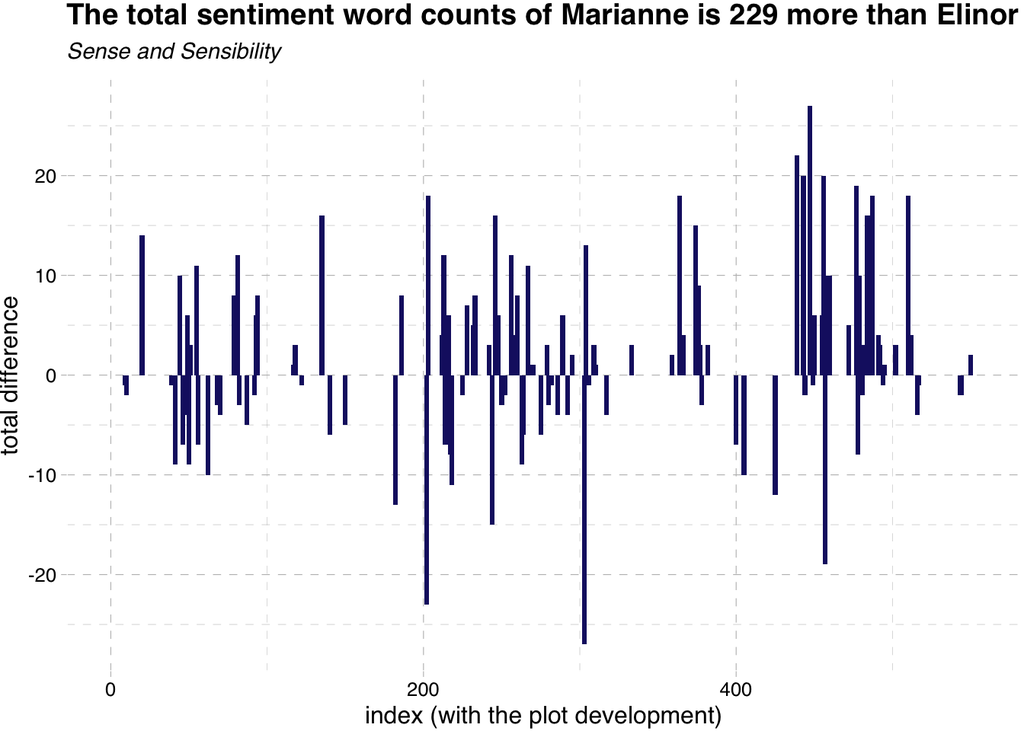

According to the plot, we can observe the different value of the sentiment word counts between Marianne and Elinor. When the bar is above the $y = 0$ axis, it means Marianne is related with more sentiment words.

Connecting with the characters in this book, I think this result is approporate. Elinor Dashwood is the sensible and reserved eldest daughter, and she represents the “sense” half of Austen’s title *Sense and Sensibility*. Marianne Dashwood is the romantically inclined and eagerly expressive second daughter, and her emotional excesses identify her as the “sensibility” half of Austen’s title. Obviously, Marianne related with more sentiment words is consistent with the characters’ personalities.

#### Explore the sentiment along with plot development

Now, I want to research the sentiment trends of these two characters along with some important plots.

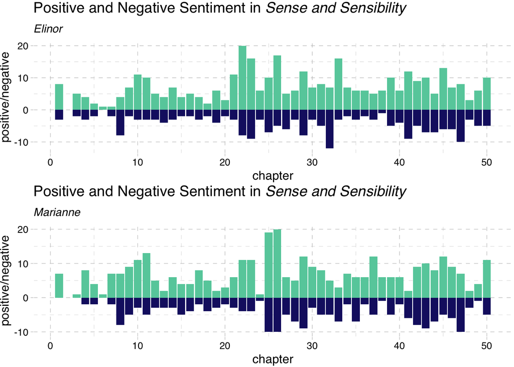

Marianne and Elinor are both positive figures in the *Sense and Sensibility*, they are kind and nice girls. And since this book is a not serious, dark story, Marianne and Elinor have more positive sentiment than negative sentiment in general.

We can also see the same sentiment trends in these following plots, which xlim is divided into more detailed segments.

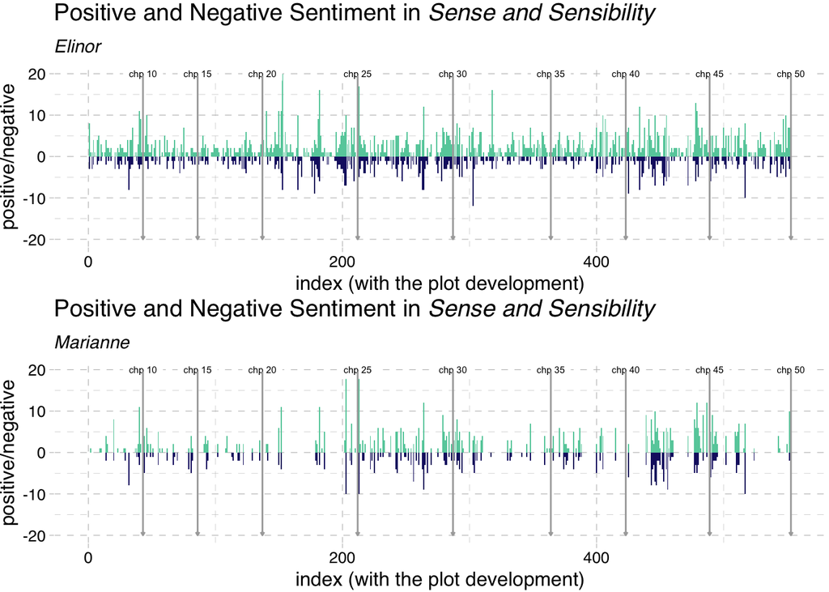

#### Co-occurence: Marianne & Willoughby | Elinor & Edward

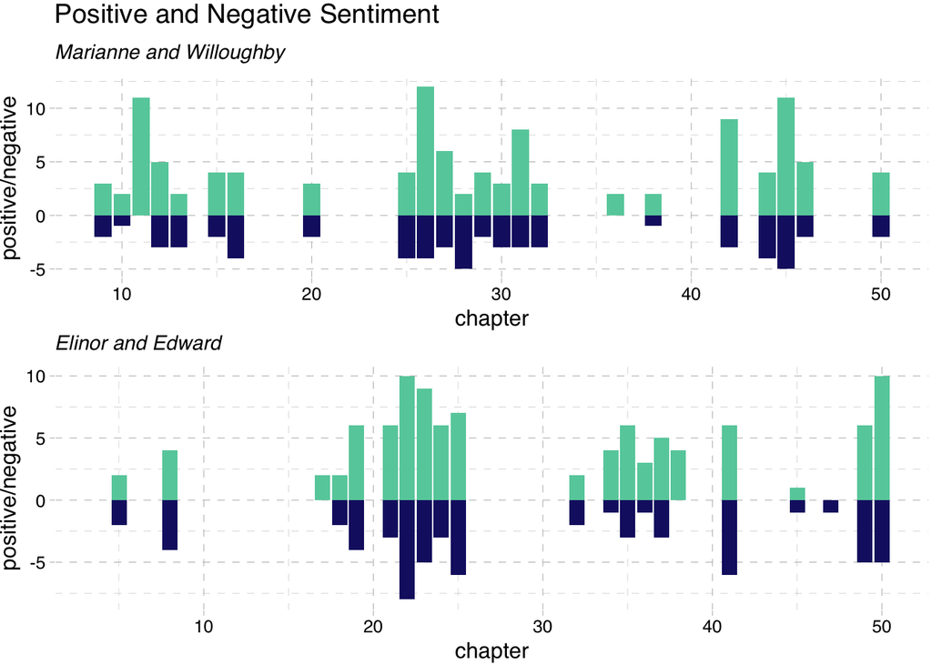

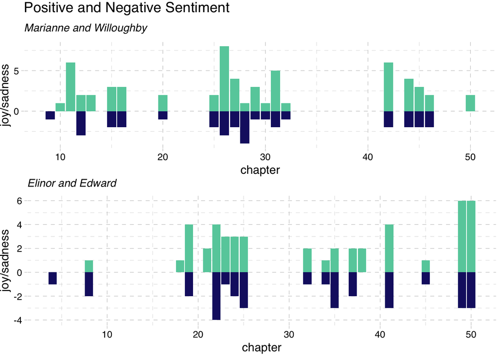

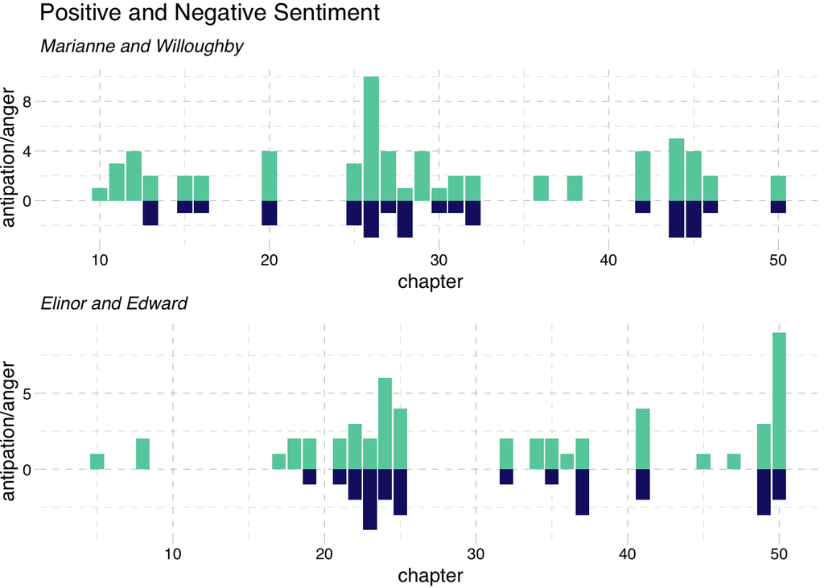

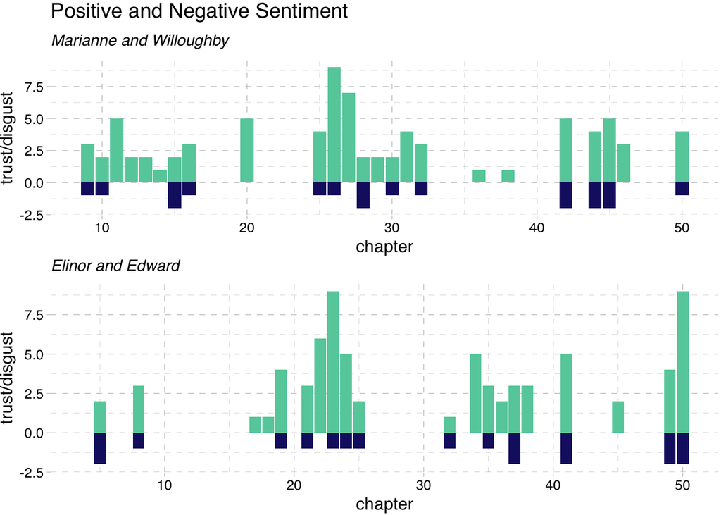

Marianne was attracted to young, handsome, romantically spirited Willoughby.  
Elinor become attached to Edward Ferrars, the brother-in-law of her elder half-brother, John.

We can observe some interesting things in these plots. For examples, - In the **trust** sentiment plot: Marianne and Willoughby’s trust sentiment increased first, then decreased. Elinor and Edward’s trust sentiment increased first, then decreased, finally increased a lot. These two observations are consistent with the content of the book. Willoughby let Marianne down in the later period and married Brandon, while Elinor and Edward got married eventually after experiencing some twists and turns.

- In the **joy** sentiment plot: In the final chapter, the joy sentiment words bars are very high since Edward proposed to Elinor and had a happy ending.

There are many other interesting things to be discovered.

#### Co-occurence of Elinor and Marianne

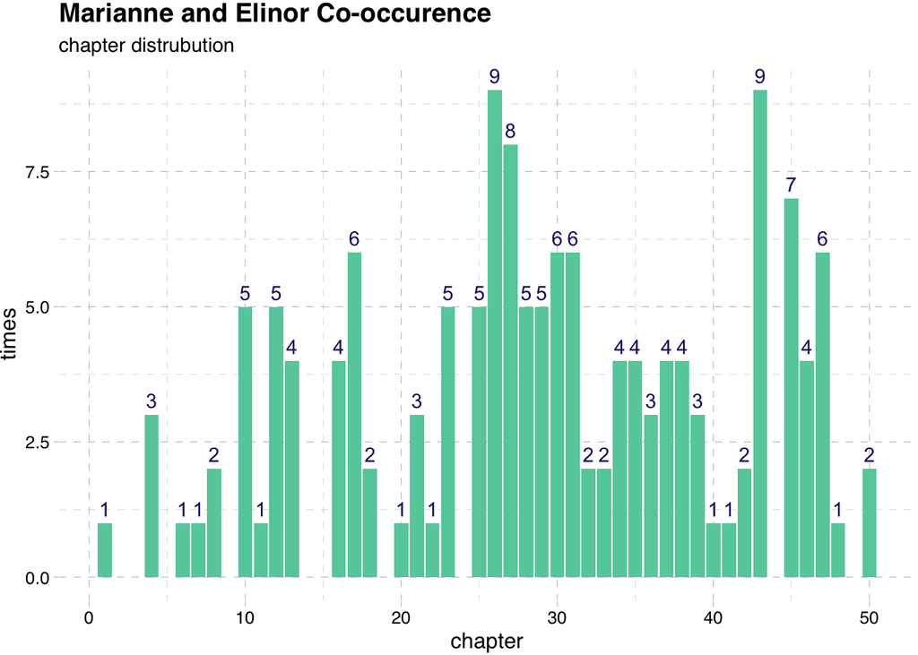

According to the plot, Elinor and Marianne co-occur most times in chapter 26 and 43. And they co-occur many times in chapter27 and 45 too.

In this book, Marianne and Elinor were always together and supported each other. I would like to use the last paragraph of *Sense and Sensibility* as the end:

> Between Barton and Delaford, there was that constant communication which strong family affection would naturally dictate;—and among the merits and the happiness of Elinor and Marianne, let it not be ranked as the least considerable, that though sisters, and living almost within sight of each other, they could live without disagreement between themselves, or producing coolness between their husbands.

## Reference

- [tnum package](https://github.com/Truenumbers/tnum)  
  we use this package for text analysis
- [get start with tnum](https://github.com/Truenumbers/tnum/tree/master/tnum/inst/Rmd)
- [jane austen package](https://github.com/juliasilge/janeaustenr)  
  This package provides access to the full texts of Jane Austen’s 6 completed, published novels.
- [`ggthemes` package](https://www.rdocumentation.org/packages/ggthemes/versions/3.5.0)